# STA237A Hw1

## Fit a polynomial

In this section, I fit a polynomial of degree 2 to the census data.

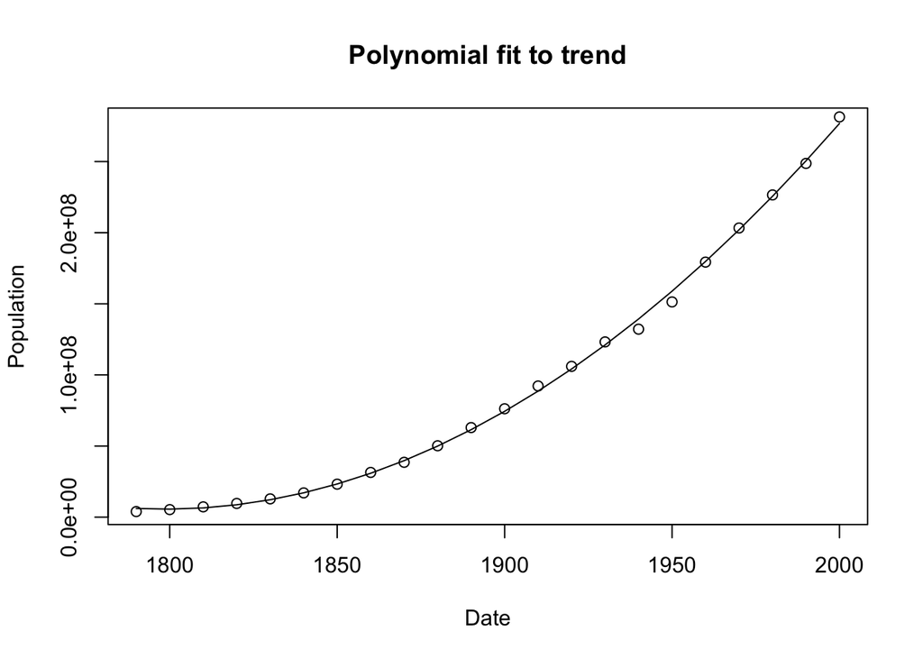

```r
m = lm(Population~poly(Date, 2, raw=TRUE), data=df)
names(m$coefficients)[2:3] = c("x1", "x2")

plt.df = data.frame(x=df$Date, y=predict(m))
plot(plt.df, type="l", main="Polynomial fit to trend",
     xlab="Date", ylab="Population")
points(df$Date, df$Population)
```

## Model diagnostics

In this section, I perform a brief analysis of the model diagnostics for the polynomial census model.

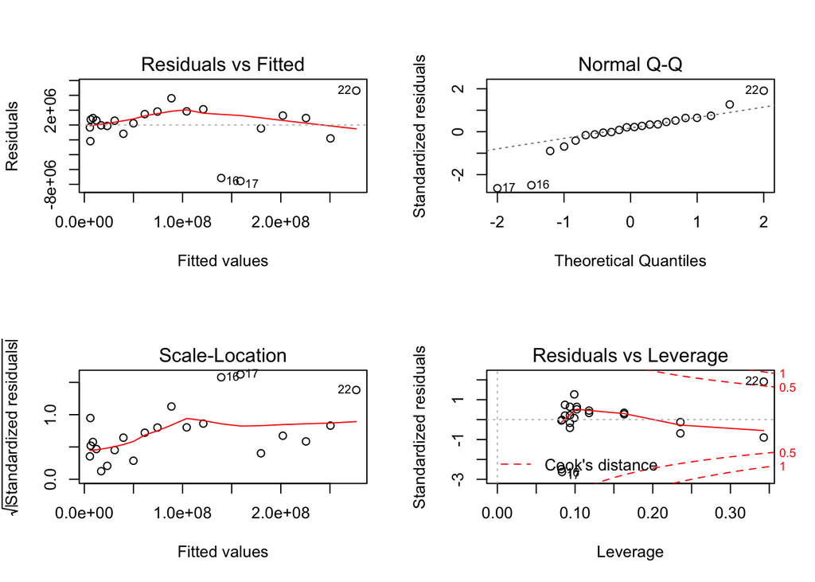

```r
par(mfrow=c(2,2))
plot(m)
```

## Predict 2010 and 2020

In this section, I use the polynomial model to predict the US population in the years 2010 and 2020.

```r
yrs = data.frame(Date=c(2010, 2020))
future_pop = predict(m, yrs)
```

The US population in 2010 may be $3.0435131\times 10^{8}$, and the population in 2020 may be $3.3327299\times 10^{8}$.

# Sources

1. http://www.econ.ohio-state.edu/dejong/note1.pdf